# Task 1 - Predict the Dependent Variable

Prakkash Manohar, IIIT Sri City

June 6, 2018

**LOADING THE DATA**

```r
options(scipen = 999)
training_data <- read.csv("D1 - Training Dataset.csv", row.names = 1)
str(training_data)    # shows the structure of the dataset
```

```
## 'data.frame':    2053 obs. of  17 variables:
##  $ Target: int  147000 147000 147000 147000 148000 148000 148000 148000 148000 149000 ...
##  $ V1    : int  859 868 876 832 835 864 831 854 811 822 ...
##  $ V2    : int  45 54 44 34 41 32 39 34 34 46 ...
##  $ V3    : int  0 0 0 0 0 0 0 0 0 0 ...
##  $ V4    : int  0 0 0 0 0 0 0 0 0 0 ...
##  $ V5    : int  0 0 1 0 0 0 0 0 0 0 ...
##  $ V6    : int  0 0 900000 0 0 0 0 0 0 0 ...
##  $ V7    : int  0 1 0 0 0 1 0 2 0 0 ...
##  $ V8    : int  0 75000 0 0 0 450000 0 350000 0 0 ...
##  $ V9    : int  0 0 0 0 1 0 1 0 1 0 ...
##  $ V10   : int  0 0 0 0 237132 0 482000 0 481775 0 ...
##  $ V11   : int  0 0 0 0 0 0 0 0 0 0 ...
##  $ V12   : int  0 0 0 0 0 0 0 0 0 0 ...
##  $ V13   : int  0 0 0 0 0 0 0 0 0 0 ...
##  $ V14   : int  0 0 0 0 0 0 0 0 0 0 ...
##  $ V15   : int  2 1 1 2 2 2 1 2 2 1 ...
##  $ V16   : int  285000 0 0 149000 0 93000 0 43000 118500 15000 ...
```

```r
print(summary(training_data))
```

```
##      Target             V1              V2              V3
##  Min.   :147000   Min.   :721.0   Min.   :25.00   Min.   :0.0000
##  1st Qu.:359000   1st Qu.:827.0   1st Qu.:34.00   1st Qu.:0.0000
##  Median :429000   Median :846.0   Median :38.00   Median :0.0000
##  Mean   :469864   Mean   :841.1   Mean   :39.47   Mean   :0.4715
##  3rd Qu.:632000   3rd Qu.:865.0   3rd Qu.:45.00   3rd Qu.:1.0000
##  Max.   :750000   Max.   :900.0   Max.   :55.00   Max.   :4.0000
##        V4                 V5              V6                 V7
##  Min.   :       0   Min.   :0.000   Min.   :       0   Min.   :0.0000
##  1st Qu.:       0   1st Qu.:0.000   1st Qu.:       0   1st Qu.:0.0000
##  Median :       0   Median :0.000   Median :       0   Median :0.0000
##  Mean   : 1437942   Mean   :0.227   Mean   :  540338   Mean   :0.1778
##  3rd Qu.: 2200000   3rd Qu.:0.000   3rd Qu.:       0   3rd Qu.:0.0000
##  Max.   :65903173   Max.   :5.000   Max.   :65903173   Max.   :4.0000
##        V8                V9              V10                V11
##  Min.   :      0   Min.   :0.0000   Min.   :       0   Min.   :0.000000
##  1st Qu.:      0   1st Qu.:0.0000   1st Qu.:       0   1st Qu.:0.000000
##  Median :      0   Median :0.0000   Median :       0   Median :0.000000
##  Mean   :  70623   Mean   :0.2372   Mean   :  183748   Mean   :0.004384
##  3rd Qu.:      0   3rd Qu.:0.0000   3rd Qu.:       0   3rd Qu.:0.000000
##  Max.   :3530000   Max.   :3.0000   Max.   :37000000   Max.   :2.000000
##       V12                 V13               V14               V15
##  Min.   :        0   Min.   :0.00000   Min.   :      0   Min.   : 0.000
##  1st Qu.:        0   1st Qu.:0.00000   1st Qu.:      0   1st Qu.: 1.000
##  Median :        0   Median :0.00000   Median :      0   Median : 1.000
##  Mean   :   106259   Mean   :0.00341   Mean   :   2319   Mean   : 1.451
##  3rd Qu.:        0   3rd Qu.:0.00000   3rd Qu.:      0   3rd Qu.: 2.000
##  Max.   :212300000   Max.   :3.00000   Max.   :1400000   Max.   :15.000
##       V16
##  Min.   :      0
##  1st Qu.:      0
##  Median :      0
##  Mean   :  67874
##  3rd Qu.: 100000
##  Max.   :1133261
```

**PRE-PROCESSING OF THE DATA/FEATURES**

```r
colSums(is.na(training_data)) # to check missing values in the dataset
```

```
## Target     V1     V2     V3     V4     V5     V6     V7     V8     V9
##      0      0      0      0      0      0      0      0      0      0
##    V10    V11    V12    V13    V14    V15    V16
##      0      0      0      0      0      0      0
```

*The above code output snippet shows that there is no NA value/missing value in any of the rows in the dataset.*

```r
# t <- training_data[duplicated(training_data),] # consists of all the duplicated values in the dataset

training_data <- training_data[!duplicated(training_data),] # removes all the duplicated values from the dataset
```

```
## After removing the duplicate rows, Dimensions of the Training Set: 2014 x 17
```

*The above code output snippet shows that the number of rows in the dataset have reduced from 2053 to 2014 which means that there were 39 duplicated rows which have been removed.*

**ANALYSIS OF THE VARIABLES/FEATURES**

*From the below code output snippets, we can infer the variables V2 (25-55), V3 (0-4), V5(0-5), V7 (0-4), V9 (0-3), V11 (0-2) and V13 (0-3) to be categorical variables/factors.*

```
##
## - - - - - - - - - - - - - - - - - - Feature V1 - - - - - - - - - - - - - -
## 721 722 724 725 726 727 728 729 730 731 732 733 734 736 740 741 742 744
##   6   1   2   1   1   1   1   3   2   1   1   5   2   2   2   1   2   1
## 746 747 748 749 751 752 753 755 756 758 759 760 762 763 764 765 766 767
##   3   1   4   1   1   3   3   2   3   3   2   6   1   1   6   2   1   4
## 768 769 770 771 772 774 775 776 777 778 779 780 781 782
##   4   1   1   3   3   2   2   4   4   5   3   1   5   3
##  and many more values...
##
## - - - - - - - - - - - - - - - - - - Feature V2 - - - - - - - - - - - - - -
##  25  26  27  28  29  30  31  32  33  34  35  36  37  38  39  40  41  42
##   3   3  12  21  36  78  78 116 122 132 133 120 102  77  78  90  70  87
##  43  44  45  46  47  48  49  50  51  52  53  54  55
##  63  72  67  69  40  38  47  43  45  44  46  37  45
##
## - - - - - - - - - - - - - - - - - - Feature V3 - - - - - - - - - - - - - -
##    0    1    2    3    4
## 1228  635  126   20    5
##
## - - - - - - - - - - - - - - - - - - Feature V4 - - - - - - - - - - - - - -
##       0   23006   81700  200000  210000  250000  300000  413149  490000
##    1230       1       1       1       1       1       1       1       1
##  500000  550000  600000  606926  621462  650000  700000  719000  730060
##       5       1       1       1       1       1       2       1       1
##  820000  862424  870000  872423  882130  944025  950000  985088  990000
##       1       1       1       1       1       1       2       1       1
## 1000000 1003087 1017252 1025000 1044850 1055341 1060161 1070093 1080000
##       8       1       1       1       1       1       1       1       1
## 1087587 1100000 1120000 1121505 1188000 1188901 1191102 1196610 1200000
##       1       6       1       1       1       1       1       1       4
## 1218697 1230215 1240000 1240029 1242916
##       1       1       1       1       1
##  and many more values...
##
## - - - - - - - - - - - - - - - - - - Feature V5 - - - - - - - - - - - - - -
##    0    1    2    3    4    5
## 1644  298   57    9    4    2
##
## - - - - - - - - - - - - - - - - - - Feature V6 - - - - - - - - - - - - - -
```

[output cut: 65 more lines]

```
##   0   1   2   3   4   5   6   8  15
## 119 974 849  47  19   2   2   1   1
##
## - - - - - - - - - - - - - - - - - - Feature V16 - - - - - - - - - - - - - -
##     0  1500  5000 10000 12000 13000 14000 14500 15000 16000 17000 18000
##  1041     1     1     6     4     1     3     1    12     5     1     5
## 19000 20000 21000 22000 22500 23000 24000 25000 26000 27000 28000 29000
##     2    18     5     4     1     3     2    17     5     1     4     1
## 30000 31000 32000 33000 33750 34000 35000 36000 37000 37500 38000 39000
##    14     3     2     2     1     4     4     3     2     2     2     1
## 40000 40500 41000 42000 43000 44000 45000 45100 46000 46500 47000 47500
##    20     1     3     4     5     5     6     1     3     2     3     1
## 48000 48500
##     1     1
##  and many more values...
```

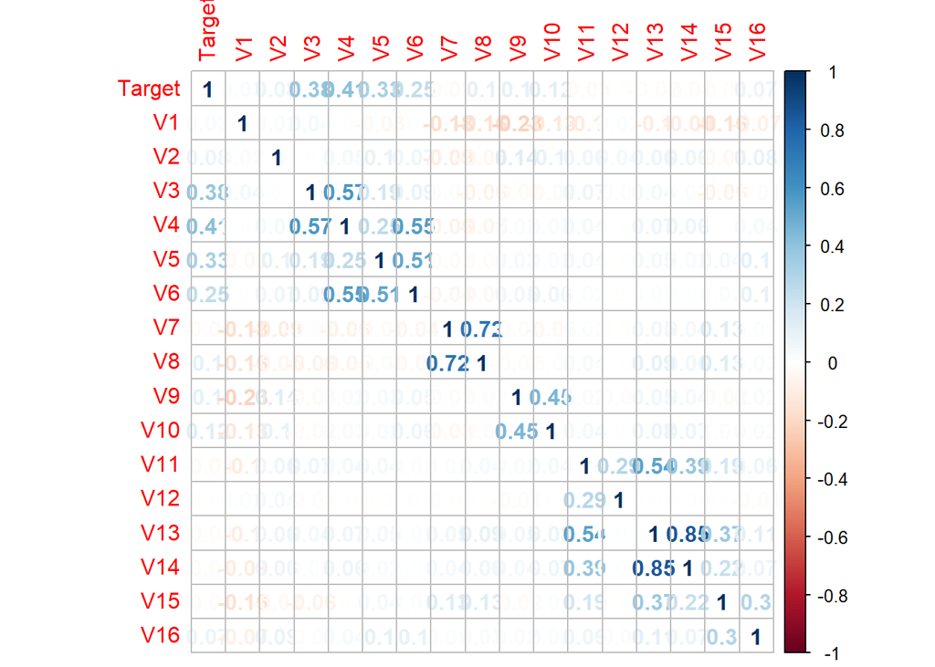

```r
#plot(training_data,col = "red") # shows pairwise plots of the different                                                                      columns/variables
#print(round(cor(total_data), 3))             # shows correlation between the different features
library(corrplot)
corrplot(cor(training_data),method='number')  # visualizes feature correlation
```

- features like v11,V12,v13,v14 are least correlated to the Target so they can be ignored for all practical purposes.
- pairs like (V13, V14) have high correlation which indicates that these pairs of features are redundant and hence, one feature in the pair will contribute very less (its coefficient will be very low) and the other will contribute high.
- data does not suffer from multicollinearity i.e. independent variables are not highly correlated so applying Regression Regularisation techniques like Ridge, Lassso & ElasticNet won’t be much useful (used in case of multicollinearity).

**SIMPLE LINEAR REGRESSION MODEL - MODEL 0**  
(Only 1 independent variable chosen)

```r
r <- -1
for(i in 2:17){
  training_data1 <- training_data[,c(1,i)]
  model <- lm(Target ~ ., data = training_data1) # uses 1 independent variables at a time
  a <- summary(model)$adj.r.squared
  if(r < a){
    r <- a
    m <- model
  }
}
model <- m
print(summary(model))
```

```
##
## Call:
## lm(formula = Target ~ ., data = training_data1)
##
## Residuals:
##      Min       1Q   Median       3Q      Max
## -1210437  -112826    -7643   124870   313357
##
## Coefficients:
##                  Estimate    Std. Error t value            Pr(>|t|)
## (Intercept) 436643.043539   4096.765926  106.58 <0.0000000000000002 ***
## V4               0.023122      0.001132   20.43 <0.0000000000000002 ***
## ---
## Signif. codes:  0 '***' 0.001 '**' 0.01 '*' 0.05 '.' 0.1 ' ' 1
##
## Residual standard error: 168100 on 2012 degrees of freedom
## Multiple R-squared:  0.1718, Adjusted R-squared:  0.1714
## F-statistic: 417.5 on 1 and 2012 DF,  p-value: < 0.00000000000000022
```

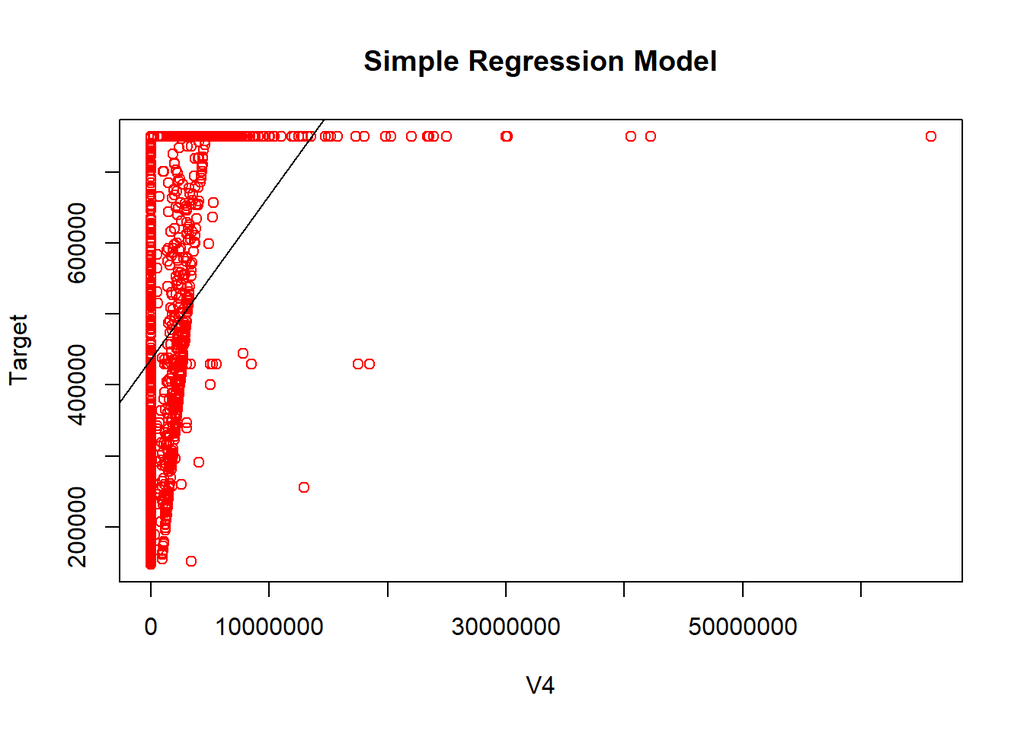

```r
plot(training_data$V4, training_data$Target, main = "Simple Regression Model", xlab = "V4", ylab = "Target", col = "red")
abline(model)
```

**It’s quite evident in the graph that simple regression model is underfitting the data. This is also supported by the fact that the Adjusted $R^{2}$ = 0.171 which is extremely low for all practical purposes.**

**MULTIPLE REGRESSION MODEL - MODEL 1**

```r
mod0 <- c(0.1714, 417.5)
full_model <- lm(Target ~ ., data = training_data) # uses all independent variables/features
print(summary(full_model))
```

```
##
## Call:
## lm(formula = Target ~ ., data = training_data)
##
## Residuals:
##     Min      1Q  Median      3Q     Max
## -720081 -112562   25985   80410  388352
##
## Coefficients:
##                    Estimate      Std. Error t value             Pr(>|t|)
## (Intercept)   97503.2307816   97843.3619681   0.997              0.31912
## V1              316.4701709     112.9422645   2.802              0.00513
## V2              613.2678701     486.2531118   1.261              0.20738
## V3            60819.1560919    6764.0841559   8.991 < 0.0000000000000002
## V4                0.0140137       0.0016285   8.605 < 0.0000000000000002
## V5            80029.0181181    7484.4015450  10.693 < 0.0000000000000002
## V6               -0.0032979       0.0020785  -1.587              0.11274
## V7           -80763.2052157   11152.8747765  -7.241    0.000000000000631
## V8                0.2047283       0.0188933  10.836 < 0.0000000000000002
## V9            22887.0450219    7645.7682805   2.993              0.00279
## V10               0.0183437       0.0039200   4.679    0.000003068783937
## V11          -97326.1213471   54544.0568065  -1.784              0.07452
## V12               0.0005578       0.0007684   0.726              0.46798
## V13         -256159.0320481   94473.9045904  -2.711              0.00676
## V14               0.2001400       0.1291279   1.550              0.12132
## V15            2308.3471208    5076.5252931   0.455              0.64937
## V16               0.0676313       0.0302005   2.239              0.02524
##
## (Intercept)
## V1          **
## V2
## V3          ***
## V4          ***
## V5          ***
## V6
## V7          ***
## V8          ***
## V9          **
## V10         ***
## V11         .
## V12
## V13         **
## V14
## V15
## V16         *
## ---
## Signif. codes:  0 '***' 0.001 '**' 0.01 '*' 0.05 '.' 0.1 ' ' 1
##
## Residual standard error: 153000 on 1997 degrees of freedom
## Multiple R-squared:  0.3194, Adjusted R-squared:  0.3139
## F-statistic: 58.56 on 16 and 1997 DF,  p-value: < 0.00000000000000022
```

**Note that Multiple $R^{2}$ = 0.3194, Adjusted $R^{2}$ = 0.3139 and F-Statistic = 58.56 for this trained multiple linear regression model. It can be seen that it has a better Adjusted $R^{2}$ value than the simple linear regression model. Still, this value is low.**

**STEPWISE REGRESSION MODEL - MODEL 2**

```r
mod1 <- c(0.3139, 58.56) # storing the R^2 value and F-Statistic Value
reduced_model <- step(full_model) # tests different combinations of features to find the best model
```

```
## Start:  AIC=48104.25
## Target ~ V1 + V2 + V3 + V4 + V5 + V6 + V7 + V8 + V9 + V10 + V11 +
##     V12 + V13 + V14 + V15 + V16
##
##        Df     Sum of Sq            RSS   AIC
## - V15   1    4840737076 46759019625996 48102
## - V12   1   12337079924 46766515968844 48103
## - V2    1   37240714624 46791419603544 48104
## <none>                  46754178888920 48104
## - V14   1   56243184116 46810422073035 48105
## - V6    1   58941827003 46813120715923 48105
## - V11   1   74542907692 46828721796611 48105
## - V16   1  117411307516 46871590196436 48107
## - V13   1  172122635089 46926301524008 48110
## - V1    1  183820926365 46937999815285 48110
## - V9    1  209787473946 46963966362866 48111
## - V10   1  512673456835 47266852345755 48124
## - V7    1 1227710046827 47981888935746 48154
## - V4    1 1733729749796 48487908638716 48176
## - V3    1 1892801817071 48646980705991 48182
## - V5    1 2676844767983 49431023656903 48214
## - V8    1 2749062982617 49503241871537 48217
##
## Step:  AIC=48102.45
## Target ~ V1 + V2 + V3 + V4 + V5 + V6 + V7 + V8 + V9 + V10 + V11 +
##     V12 + V13 + V14 + V16
##
##        Df     Sum of Sq            RSS   AIC
## - V12   1   12433925087 46771453551083 48101
## - V2    1   35767722162 46794787348158 48102
## <none>                  46759019625996 48102
## - V14   1   52114827105 46811134453101 48103
## - V6    1   59991939657 46819011565653 48103
## - V11   1   76117382561 46835137008557 48104
## - V16   1  141754459891 46900774085887 48107
## - V13   1  171792183087 46930811809083 48108
## - V1    1  179462424283 46938482050280 48108
## - V9    1  206560087417 46965579713413 48109
## - V10   1  513096614708 47272116240704 48122
## - V7    1 1222919682027 47981939308023 48152
```

[output cut: 30 more lines]

```
##        Df     Sum of Sq            RSS   AIC
## <none>                  46808606588545 48101
## - V14   1   58121502216 46866728090761 48101
## - V11   1   60119216376 46868725804920 48101
## - V6    1   61439942017 46870046530562 48101
## - V16   1  152450904722 46961057493266 48105
## - V13   1  192030322532 47000636911076 48107
## - V1    1  193513051678 47002119640223 48107
## - V9    1  229531636805 47038138225350 48108
## - V10   1  522308902341 47330915490886 48121
## - V7    1 1262633145931 48071239734476 48152
## - V4    1 1761039832076 48569646420621 48173
## - V3    1 1870341787943 48678948376487 48177
## - V5    1 2742288293701 49550894882245 48213
## - V8    1 2770083270845 49578689859389 48214
```

```r
print(summary(reduced_model))
```

```
##
## Call:
## lm(formula = Target ~ V1 + V3 + V4 + V5 + V6 + V7 + V8 + V9 +
##     V10 + V11 + V13 + V14 + V16, data = training_data)
##
## Residuals:
##     Min      1Q  Median      3Q     Max
## -722013 -113813   26050   79719  388067
##
## Coefficients:
##                   Estimate     Std. Error t value             Pr(>|t|)
## (Intercept)  119983.300793   94952.554938   1.264              0.20652
## V1              321.918790     111.953856   2.875              0.00408 **
## V3            60153.646803    6728.981459   8.939 < 0.0000000000000002 ***
## V4                0.014108       0.001626   8.674 < 0.0000000000000002 ***
## V5            80766.638982    7461.451397  10.825 < 0.0000000000000002 ***
## V6               -0.003365       0.002077  -1.620              0.10534
## V7           -81472.687312   11092.292344  -7.345    0.000000000000298 ***
## V8                0.205435       0.018883  10.879 < 0.0000000000000002 ***
## V9            23736.825103    7579.651043   3.132              0.00176 **
## V10               0.018505       0.003917   4.724    0.000002472584745 ***
## V11          -81982.971188   51152.263596  -1.603              0.10915
## V13         -253676.563324   88561.160427  -2.864              0.00422 **
## V14               0.199680       0.126711   1.576              0.11521
## V16               0.073865       0.028941   2.552              0.01078 *
## ---
## Signif. codes:  0 '***' 0.001 '**' 0.01 '*' 0.05 '.' 0.1 ' ' 1
##
## Residual standard error: 153000 on 2000 degrees of freedom
## Multiple R-squared:  0.3186, Adjusted R-squared:  0.3141
## F-statistic: 71.92 on 13 and 2000 DF,  p-value: < 0.00000000000000022
```

**Note that Multiple $R^{2}$ = 0.3186, Adjusted $R^{2}$ = 0.3141 and F-Statistic = 71.92 for this trained stepwise regression model which doesn’t show any improvement over the previous model.**

**STEPWISE REGRESSION WITH OUTLIERS REMOVED - MODEL 3**

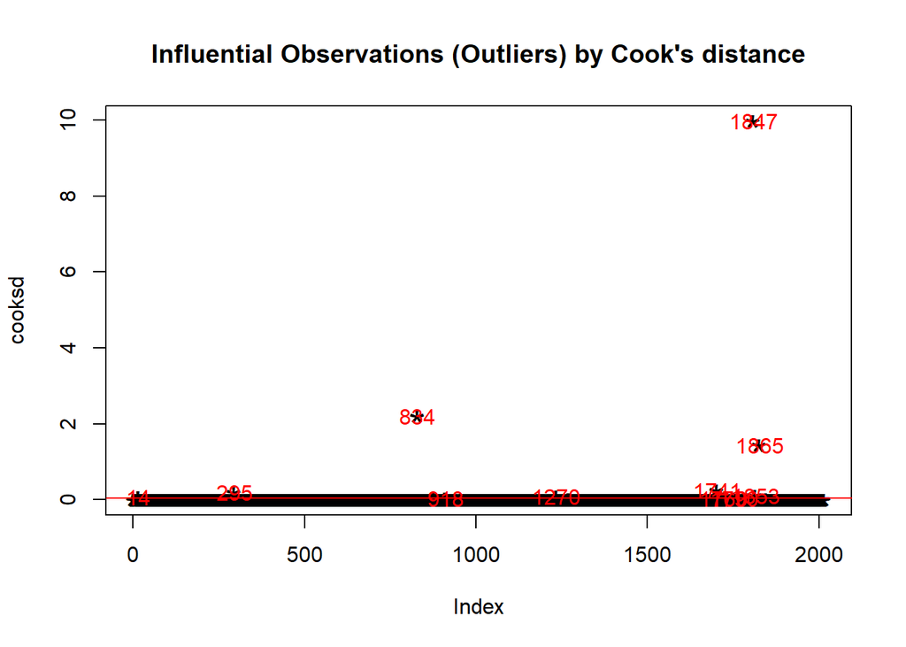

```r
mod2 <- c(0.3141, 71.92) # storing the R^2 value and F-Statistic Value
cooksd <- cooks.distance(reduced_model)
plot(cooksd, pch="*", cex=2, main="Influential Observations (Outliers) by Cook's distance")
# plot cook's distance
abline(h = 4*mean(cooksd, na.rm=T), col="red")  # add cutoff line
text(x=1:length(cooksd)+1, y=cooksd, labels=ifelse(cooksd>4*mean(cooksd, na.rm=T),names(cooksd),""), col="red")  # add labels
```

```r
outliers <- which(cooksd>4*mean(cooksd, na.rm=T))
print(outliers)
```

```
##   14  295  834  918 1270 1741 1760 1790 1847 1853 1865
##   14  295  828  910 1233 1702 1721 1751 1808 1814 1826
```

```r
training_data_new <- training_data[-outliers,]
full_model_new <- lm(Target ~ ., data = training_data_new)
#print(summary(full_model_new))
reduced_model_without_outlier <- step(full_model_new)
```

```
## Start:  AIC=47665.79
## Target ~ V1 + V2 + V3 + V4 + V5 + V6 + V7 + V8 + V9 + V10 + V11 +
##     V12 + V13 + V14 + V15 + V16
##
##        Df     Sum of Sq            RSS   AIC
## - V13   1     562468439 42590002953010 47664
## - V14   1    1055014126 42590495498697 47664
## - V15   1    3593606371 42593034090942 47664
## - V12   1    6866130925 42596306615496 47664
## - V9    1   16030259551 42605470744123 47665
## - V2    1   20935930183 42610376414754 47665
## - V11   1   21935709134 42611376193705 47665
## <none>                  42589440484571 47666
## - V16   1   46871955774 42636312440346 47666
## - V1    1   84116114084 42673556598655 47668
## - V6    1  151926923468 42741367408039 47671
## - V3    1  783404962796 43372845447367 47700
## - V10   1  948523421568 43537963906139 47708
## - V7    1 1191614817634 43781055302205 47719
## - V5    1 1533778117140 44123218601711 47735
## - V8    1 2683548184746 45272988669318 47786
## - V4    1 3310457988116 45899898472687 47814
##
## Step:  AIC=47663.82
## Target ~ V1 + V2 + V3 + V4 + V5 + V6 + V7 + V8 + V9 + V10 + V11 +
##     V12 + V14 + V15 + V16
##
##        Df     Sum of Sq            RSS   AIC
## - V14   1    3156468523 42593159421533 47662
## - V15   1    3604403222 42593607356231 47662
## - V12   1    7433405232 42597436358242 47662
## - V9    1   15962676887 42605965629897 47663
## - V2    1   21232236350 42611235189360 47663
## - V11   1   26833692577 42616836645587 47663
## <none>                  42590002953010 47664
## - V16   1   46488498158 42636491451168 47664
## - V1    1   84928915590 42674931868600 47666
## - V6    1  152136773801 42742139726811 47669
## - V3    1  783757150025 43373760103035 47698
## - V10   1  948368052480 43538371005490 47706
```

[output cut: 98 more lines]

```
##
## Step:  AIC=47654.84
## Target ~ V1 + V3 + V4 + V5 + V6 + V7 + V8 + V10 + V16
##
##        Df     Sum of Sq            RSS   AIC
## <none>                  42654349615098 47655
## - V16   1   65662628867 42720012243965 47656
## - V1    1  108246744164 42762596359263 47658
## - V6    1  154628570434 42808978185532 47660
## - V3    1  763447441429 43417797056527 47688
## - V7    1 1208757279224 43863106894323 47709
## - V5    1 1563888097361 44218237712459 47725
## - V10   1 1593374177607 44247723792706 47726
## - V8    1 2691762875033 45346112490131 47775
## - V4    1 3372163372337 46026512987435 47805
```

```r
print(summary(reduced_model_without_outlier))
```

```
##
## Call:
## lm(formula = Target ~ V1 + V3 + V4 + V5 + V6 + V7 + V8 + V10 +
##     V16, data = training_data_new)
##
## Residuals:
##     Min      1Q  Median      3Q     Max
## -643965 -107667   32792   71344  385001
##
## Coefficients:
##                  Estimate    Std. Error t value             Pr(>|t|)
## (Intercept) 186347.828175  89716.422276   2.077              0.03792 *
## V1             238.476920    106.039323   2.249              0.02462 *
## V3           41353.133763   6923.837507   5.973   0.0000000027584894 ***
## V4               0.023606      0.001881  12.552 < 0.0000000000000002 ***
## V5           68016.513463   7956.820152   8.548 < 0.0000000000000002 ***
## V6               0.007420      0.002760   2.688              0.00725 **
## V7          -82600.447243  10991.092438  -7.515   0.0000000000000853 ***
## V8               0.219040      0.019531  11.215 < 0.0000000000000002 ***
## V10              0.054873      0.006360   8.628 < 0.0000000000000002 ***
## V16              0.048771      0.027844   1.752              0.08000 .
## ---
## Signif. codes:  0 '***' 0.001 '**' 0.01 '*' 0.05 '.' 0.1 ' ' 1
##
## Residual standard error: 146300 on 1993 degrees of freedom
## Multiple R-squared:  0.3734, Adjusted R-squared:  0.3705
## F-statistic: 131.9 on 9 and 1993 DF,  p-value: < 0.00000000000000022
```

**Note that Multiple $R^{2}$ = 0.3734, Adjusted $R^{2}$ = 0.3705 and F-Statistic = 131.9 for this trained regression model without outliers which shows improvement but it is still low.**

**PREDICTION, VALIDATION & DIAGNOSTICS**

```r
library(rcompanion)
mod3 <- c(0.3705, 131.9)
validation_data <- read.csv("D2 - Validation Dataset.csv", row.names = 1)
pvd <- function(data, model){
  rmse <- accuracy(list(model),plotit=FALSE, digits=3)$Fit.criteria[1,"RMSE"]
  #rmse <- round(rmse,2)
  # MSE should be as low as possible

  # min_max_accuracy <- mean(apply(data[,c(1:2)], 1, min)/apply(data[,c(1:2)], 1, max))
  # min_max_accuracy <- round(min_max_accuracy*100,2)
  # min_max_accuracy <- paste(toString(min_max_accuracy),"%", sep = " ")
  # # MIN MAX ACCURACY should be as high as possible
  #
  # mape <- accuracy(list(model),plotit=FALSE, digits=3)$Fit.criteria[1,"MAPE"]
  # mape <- round(mape*100,2)
  # mape <- paste(toString(mape),"%", sep = " ")
  # # MAPE should be as low as possible

  # result = c(rmse, min_max_accuracy, mape)
 return(rmse)
}

#predicted_values <- predict(reduced_model_without_outlier, validation_data)
#validation_data_1 <- cbind(validation_data, Predicted = predicted_values)
#validation_data_1 <- validation_data_1[,c(1, 18, 2:17)]
#write.csv(validation_data_1, file = "Validation_Dataset_with_predicted.csv")

valfun <- function(model){
  predicted_values <- predict(model, newdata = validation_data)
  validation_data_1 <- cbind(validation_data, Predicted = predicted_values)
  validation_data_1 <- validation_data_1[,c(1, 18, 2:17)]
  return(validation_data_1)
}

predicted_values <- predict(model, newdata = validation_data)
validation_data_1 <- data.frame(Target = validation_data$Target, Predicted = predicted_values)
model0 <- pvd(validation_data_1, model)
model0 <- c(model0, mod0)
validation_data_1 <- valfun(full_model)
model1 <- pvd(validation_data_1, full_model)
model1 <- c(model1, mod1)
validation_data_1 <- valfun(reduced_model)
model2 <- pvd(validation_data_1, reduced_model)
model2 <- c(model2, mod2)
validation_data_1 <- valfun(reduced_model_without_outlier)
model3 <- pvd(validation_data_1, reduced_model_without_outlier)
model3 <- c(model3, mod3)

df = data.frame(model0, model1, model2, model3)
df[1,] <- lapply(df[1,], format)
colnames(df) <- c("Model 0 - Simple Linear Regression", "Model 1 - Multiple Regression", "Model 2 - Stepwise Regression", "Model 3 - Stepwise Regression with NO outliers")
rownames(df) <- c("Root Mean Square Error", "Adjusted R^2 Value", "F-Statistic Value")

# actuals_preds <- data.frame(validation_data_1$Target, validation_data_1$Predicted)
# correlation_accuracy <- cor(actuals_preds)
# print(correlation_accuracy)
```

Linear Model Diagnostics

|  | Model 0 - Simple Linear Regression | Model 1 - Multiple Regression | Model 2 - Stepwise Regression | Model 3 - Stepwise Regression with NO outliers |
| --- | --- | --- | --- | --- |
| Root Mean Square Error | 168000 | 152000 | 152000 | 146000 |
| Adjusted R^2 Value | 0.1714 | 0.3139 | 0.3141 | 0.3705 |
| F-Statistic Value | 417.5 | 58.56 | 71.92 | 131.9 |

**It’s evident from the table that Model 3 has performed the best among the 4 models based on most of the parameters. Now, close inspection of the values tells us that Model 0 i.e. the simple linear regression model has performed the worst (which was expected also) since it took only 1 independent variable into consideration. Model 1 is better than Model 0 as it includes all the independent variables. Model 2 has performed almost the same as Model 1. Model 3 has performed even better as it is devoid of the outliers that were present in Model 2.**

**LOOKING AT SOME DIAGNOSTIC PLOTS**

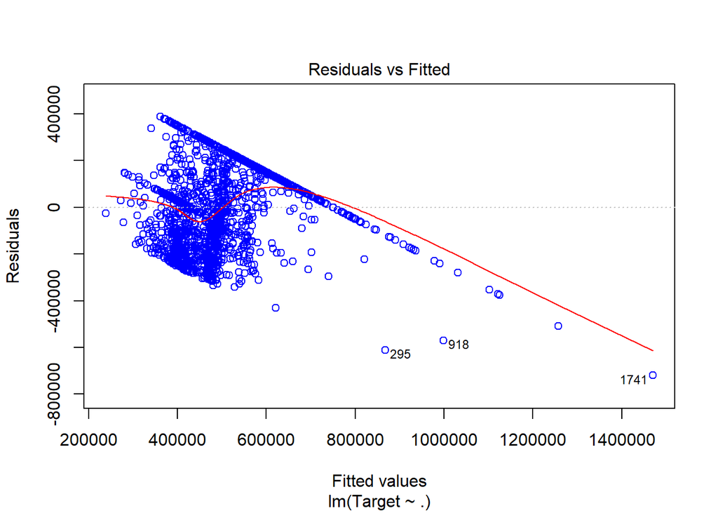

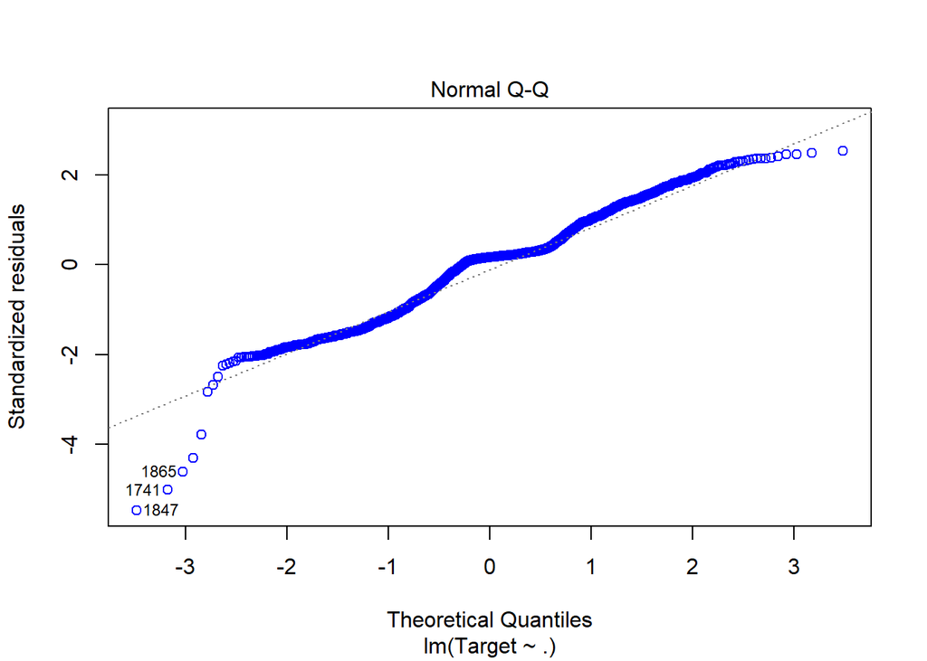

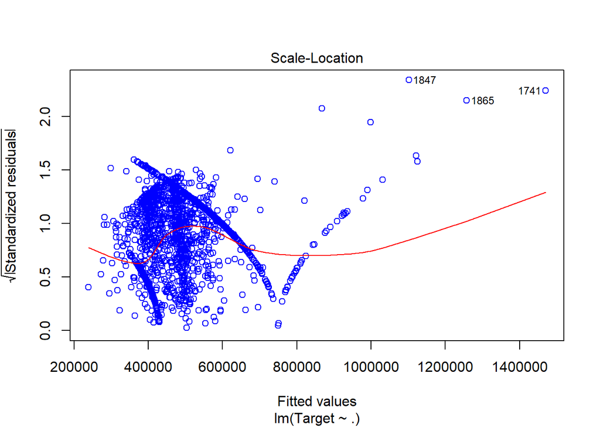

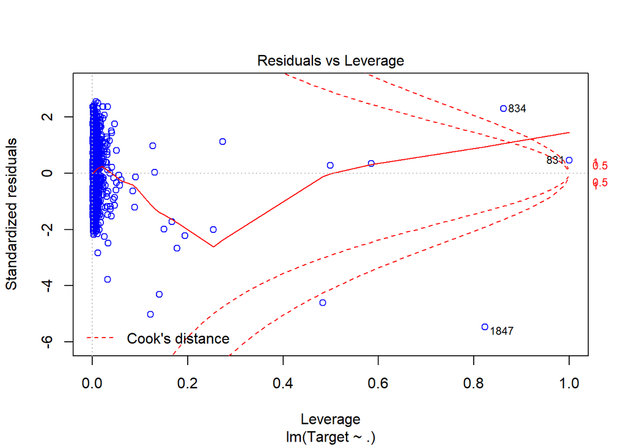

```r
plot(full_model, col="blue")
```

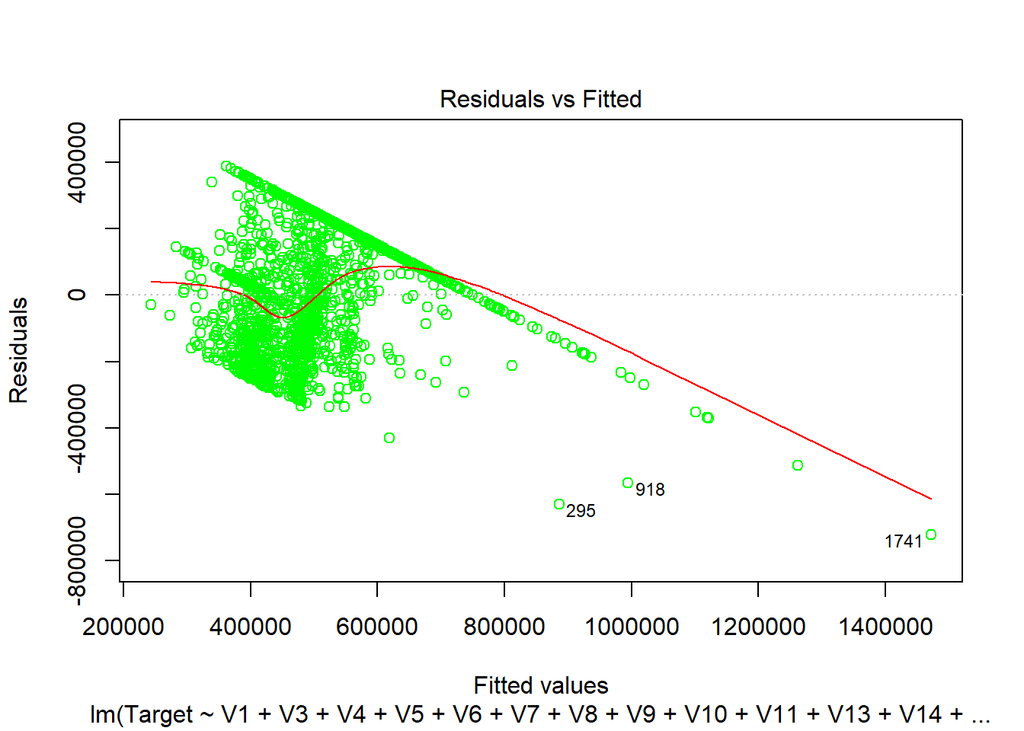

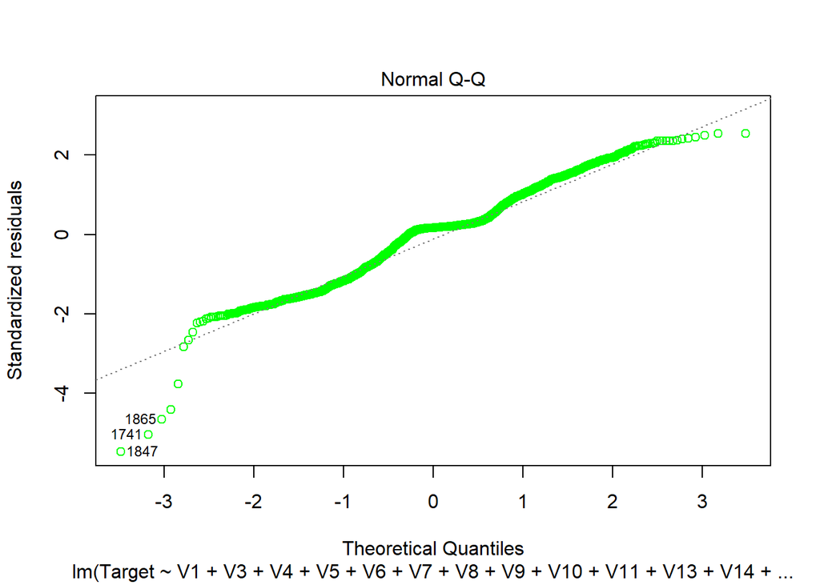

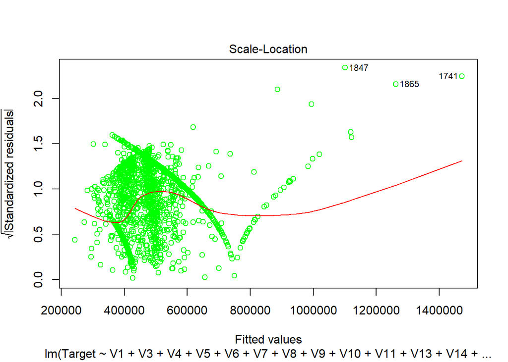

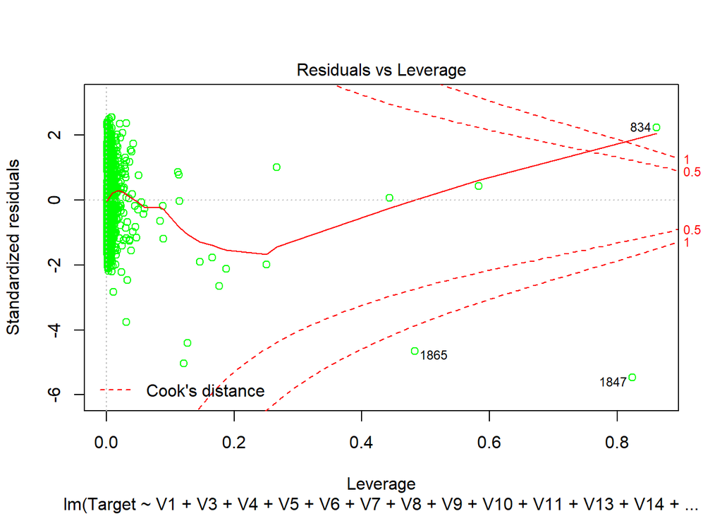

```r
plot(reduced_model, col="green")
```

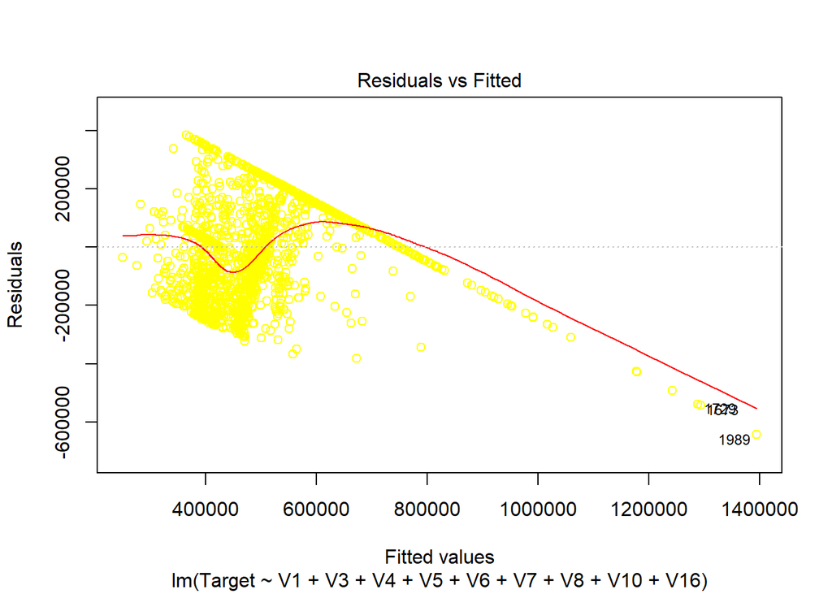

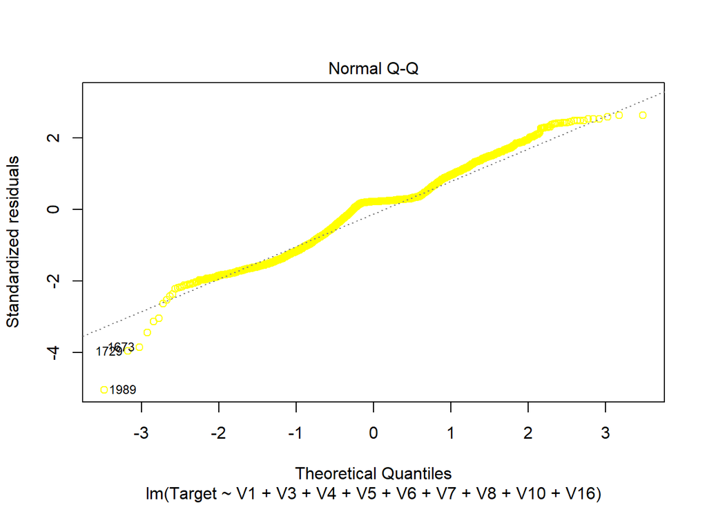

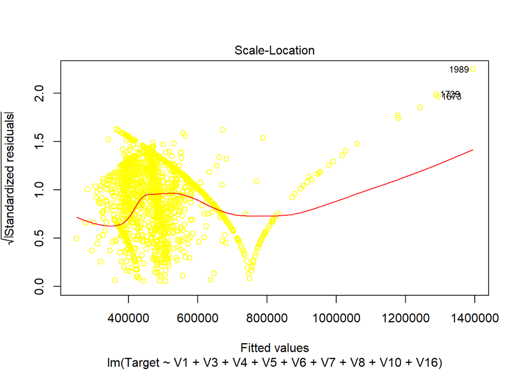

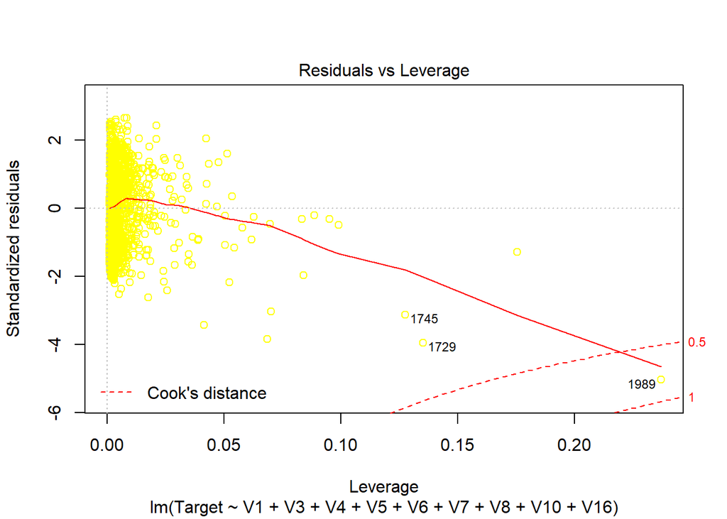

```r
plot(reduced_model_without_outlier, col="yellow")
```

**From the last green plot (Residuals VS Leverage for Model 2), we can see some of the outliers like 834, 1865 & 1847 lying outside the Cook’s Distance inner region. These 3 outliers were also seen in the Cook’s Distance VS index graph above (Regression without outliers - Model 3). Hence, both of them are in accordance with each other.**

**DECISION TREE - MODEL 4**

```r
training_data_new <- training_data
validation_data <- read.csv("D2 - Validation Dataset.csv", row.names = 1)

adj.r.sq <- function(r.sq, n, p){ # n = sample size, p = no. of predictors
  adj.r <- 1 - ((1-r.sq)*(n-1)/(n-p-1))
  return (adj.r)
}

library (party)
# library(partykit)
library(caret)

fit <- ctree (Target ~ ., training_data_new)  # build the tree model
#print(fit)
# st <- as.simpleparty(fit)
# plot(st)
tree_pred <- predict(fit, validation_data)
#mean((tree_pred - validation_data[,"Target"])^2) # mse of 15528880796 which is even lower
prs <- postResample(pred = tree_pred, obs = validation_data[,"Target"])
adj.r <- adj.r.sq(prs["Rsquared"], nrow(validation_data), 9)     # 0.5370369, 0.5531
adj.r <- round(adj.r, 4)
rmse <- prs["RMSE"]   # 124614.9, 122338.5
rmse <- round(rmse, 4)
paste("Adjusted R^2 value for Decision Tree:",adj.r, sep = " ")
```

```
## [1] "Adjusted R^2 value for Decision Tree: 0.537"
```

```r
paste("Root Mean Square Error for Decision Tree:",format(rmse), sep = " ")
```

```
## [1] "Root Mean Square Error for Decision Tree: 124614.9"
```

[figure not shown]

```r
plot (fit, main="Conditional Inference Tree")  # the ctree
```

```r
model4 <- c(rmse, adj.r)
```

```r
df1 <- df
df1 <- df1[-3,]
df1 <- df1[,-c(2,3)]
df1 <- cbind(df1, "Decision Tree" = model4)
df1[1,3] <- format(round(df1[1,3], 0))
colnames(df1) <- c("Simple Linear Regression", "Stepwise Regression with NO outliers", "Decision Tree")
```

Model wise Diagnostics

|  | Simple Linear Regression | Stepwise Regression with NO outliers | Decision Tree |
| --- | --- | --- | --- |
| Root Mean Square Error | 168000 | 146000 | 124615 |
| Adjusted R^2 Value | 0.1714 | 0.3705 | 0.537 |

**It can be inferred that Decision Tree is the best model among the three shown above. Simple Linear Regression is too simple/underfitting for the data which is also clear by the fact that it has the highest RMSE. Decision Tree has the lowest RMSE. Its Adjusted $R^{2}$ value is just written for a reference; Adjusted $R^{2}$ value is not a good performance metric for a decision tree so it’s not considered usually.**